# 人工智能知識及應用證書（兼讀制）實習一

Date : Oct-2021 v1

### Learning Objective

- As AI will soon be everywhere, everyone should have the right skill set to understand an AI model. This tutorial is to demonstrate for beginners how to build Neural Network models in R to solve problems
- Students may follow the instructions and gain hands-on experience buiding an AI model.
- This is a low-code tutorial in R

### Tools

- R : [R](https://www.r-project.org/) is a programming language and free software environment for statistical computing and graphics supported by the R Foundation for Statistical Computing.
- [rstudio.cloud](https://rstudio.cloud/) : Studio Cloud is created with an aim to make it easy for professionals, hobbyists, trainers, teachers and students to practice, share, teach and learn data science. In the basic term, RStudio Cloud is a managed cloud instance of the RStudio IDE.  
  **Question** Is R language popular?  
  **Question** Is Rstudio gaining popularity?

```r
install.packages(pkgs='neuralnet')
```

Task 1: Install the [R package](https://en.wikipedia.org/wiki/R_package) “[neuralnet](https://cran.r-project.org/web/packages/neuralnet/index.html)”.  
R is a case-sensitive language. Install.packages is incorrect!  
A package is a toolbox for doing things for a specific computer language.  
In many computer languages, ‘123’ or “123” is a text while 123 is a number.  
install.packages is a function. The input of the function is ‘neuralnet’  
**Question** Can we install RStudio IDE on PC?

```r
library(package='neuralnet')
```

Task 2: Load the package ‘neuralnet’.  
The library function is to load a specific package.  
**Question** Do we have to load the package after we start a new R session?  
**Question** Could we load the package twice?

```r
rawdata = "
 age , smoking, cancer
 35  ,  0 , 0
 40  ,  1 , 0
 45  ,  0 , 1
 55  ,  1 , 1"

trainData = read.csv(text=rawdata , header=TRUE)

print(trainData)
```

| age | smoking | cancer |
| --- | --- | --- |
| 35 | 0 | 0 |
| 40 | 1 | 0 |
| 45 | 0 | 1 |
| 55 | 1 | 1 |

Task 3: Data Preparation  
We have a small data set (four records).  
The meaning of data is self-explanatory.  
**Question** What is [csv](https://www.businessinsider.com/what-is-csv-file)?  
**Question** How will we find out if a person who is age=50 and smoking=1 will get cancer? (Note that we will not adopt any special math formula or if-then logic)  
**Question** What happens if header=FALSE?

```r
model=neuralnet(formula       =  cancer~age+smoking  ,
                data          =  trainData           ,
                hidden        =  3                   ,
                stepmax       =  1e+05               ,
                act.fct       = "logistic"           ,
                linear.output = FALSE                )
```

Task 4: Model  
Note 1e+05=100000  
Build an artificial neural network model of hidden=3

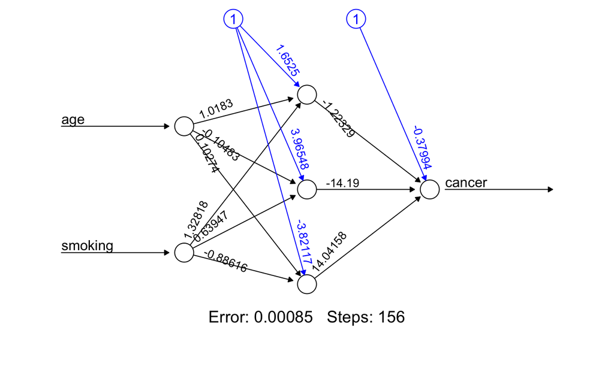

```r
plot(model)
```

Task 5: Neural Network’s Structure Diagrams  
The model can be visualized as shown above.  
**Question** Where are [neurons](https://towardsdatascience.com/the-differences-between-artificial-and-biological-neural-networks-a8b46db828b7)?  
**Question** Which one is hidden layer?  
**Question** If we re-do Task 4 and Task 5 again, will we get the same model?  
**Question** What happens if we change stepmax=5

```r
predictData=neuralnet::compute(model, data.frame(age=50, smoking=1))
print(predictData)
```

```
$neurons
$neurons[[1]]
       age smoking
[1,] 1  50       1

$neurons[[2]]
     [,1] [,2]      [,3]      [,4]
[1,]    1    1 0.3459816 0.6057696


$net.result
          [,1]
[1,] 0.8800862
```

Task 6: Prediction  
The result value is close to 1  
Thus, there is a high chance to get cancer.  
**Question** what about age=43?  
**Question** what about age=100?  
**Question** If we have more training data, will the model be better? Explain.

### Exercises

[1] One more variabe, drinking, is added as below

```r
rawdata = "
 age , smoking, drinking, cancer
 25  ,  1 , 1, 0
 30  ,  1 , 0, 0
 35  ,  0 , 1, 1
 38  ,  1 , 1, 1
 40  ,  1 , 1, 0
 45  ,  1 , 0, 0
 45  ,  1 , 1, 0
 47  ,  0 , 1, 1
 49  ,  1 , 1, 1
 55  ,  1 , 1, 1"
```

Build a model to solve a case that a person who is age=30, smoking=1, drinking=1 may get cancer.  
[2] Redo the exercise 1 with the model of hidden=c(3,3)

```r
model=neuralnet(formula       = cancer~age+smoking ,
                data          = trainData          ,
                hidden        = c(3,3)             ,
                act.fct       = "logistic"         ,
                linear.output = FALSE              )
plot(model)
```

### Reference

[1] Whenever i run my neural network I get different result.  
https://www.researchgate.net/post/Whenever-i-run-my-neural-network-I-get-different-result  
[2] What Is RStudio Cloud And Why Is It Gaining Popularity  
https://analyticsindiamag.com/what-is-rstudio-cloud-and-why-is-it-gaining-popularity/  
[3] R for Economics and Finance: Getting research data  
http://rstudio-pubs-static.s3.amazonaws.com/41274_b888794c95b84e6b937c1099202380c4.html  
[4] neuralnet  
https://github.com/cran/neuralnet/tree/master/R